# 01_RQ1_differential expression

- Show All Code
- Hide All Code
- View Source

Author

Lun Suša (s253705)

Published

November 25, 2026

Which genes are differentially expressed between patients with complete response and patients with progressive disease following anti-PD-L1 treatment?

### Load packages

```r
library(tidyverse)
library(DESeq2)
library(fgsea)
library(msigdbr)
library(pheatmap)


# specify filter
filter <- dplyr::filter
```

## Data exploration

```r
prepared <- readRDS("../data/processed/imvigor210_prepared.rds")

dds  <- prepared$dds
meta <- as.data.frame(colData(dds))

# size of the data
cat("Genes x samples:", dim(counts(dds)), "\n")
```

```
Genes x samples: 18226 192
```

```r
# what groups exist, and how many samples in each
cat("Samples per group (BOR):")
```

```
Samples per group (BOR):
```

```r
print(table(meta$BOR, useNA = "ifany"))
```

```
 NR   R
167  25
```

```r
# are counts and metadata in the same order
cat("Count matrix columns match metadata rows:",
    all(colnames(counts(dds)) == rownames(meta)))
```

```
Count matrix columns match metadata rows: TRUE
```

This shows that the count matrix has 18,226 genes × 192 samples after running the low-expression filter from the preparation notebook (genes with more than 10 counts in at least 10 samples). There are 25 complete response (R) and 167 progressive disease (non responders?) (NR), with no missing values. This is an extremely unbalanced representation and reduces statistical power!!

## Fitted model, DE genes

```r
design(dds)
```

```
~BOR
```

**limitation**: model is not adjusted for TMB, sequencing depth (other than size factors), and where the samples were taken from

DESeq was already done during data preparation, so now I just have to check it. It did size-factor normalization, dispersion estimation, Wald test for BOR.

```r
levels(factor(dds$BOR)) # NR is the reference
```

```
[1] "NR" "R"
```

```r
resultsNames(dds)
```

```
[1] "Intercept"   "BOR_R_vs_NR"
```

```r
summary(sizeFactors(dds))
```

```
   Min. 1st Qu.  Median    Mean 3rd Qu.    Max.
 0.2620  0.8036  1.0329  1.0629  1.3073  1.9526
```

```r
res <- results(dds) # default
summary(res)
```

```
out of 18226 with nonzero total read count
adjusted p-value < 0.1
LFC > 0 (up)       : 290, 1.6%
LFC < 0 (down)     : 491, 2.7%
outliers [1]       : 0, 0%
low counts [2]     : 0, 0%
(mean count < 1)
[1] see 'cooksCutoff' argument of ?results
[2] see 'independentFiltering' argument of ?results
```

```r
res_sig <- results(dds, alpha = 0.05) # stricter
summary(res_sig)
```

```
out of 18226 with nonzero total read count
adjusted p-value < 0.05
LFC > 0 (up)       : 167, 0.92%
LFC < 0 (down)     : 289, 1.6%
outliers [1]       : 0, 0%
low counts [2]     : 0, 0%
(mean count < 1)
[1] see 'cooksCutoff' argument of ?results
[2] see 'independentFiltering' argument of ?results
```

NR is the reference: log2fold change:  
positive -> higher expression in complete responders  
negative -> higher expression in progressive disease

**Size factors**  
0.26 to 1.95 (median 1.03)  
centered near 1, so normalization worked, a few samples have lower sequencing depth

```r
# more about size factors
cat("Size factors by response group:\n")
```

```
Size factors by response group:
```

```r
print(tapply(meta$sizeFactor, meta$BOR, summary))
```

```
$NR
   Min. 1st Qu.  Median    Mean 3rd Qu.    Max.
 0.2620  0.8054  1.0165  1.0522  1.2742  1.9526

$R
   Min. 1st Qu.  Median    Mean 3rd Qu.    Max.
 0.4720  0.7874  1.1356  1.1347  1.4175  1.7800
```

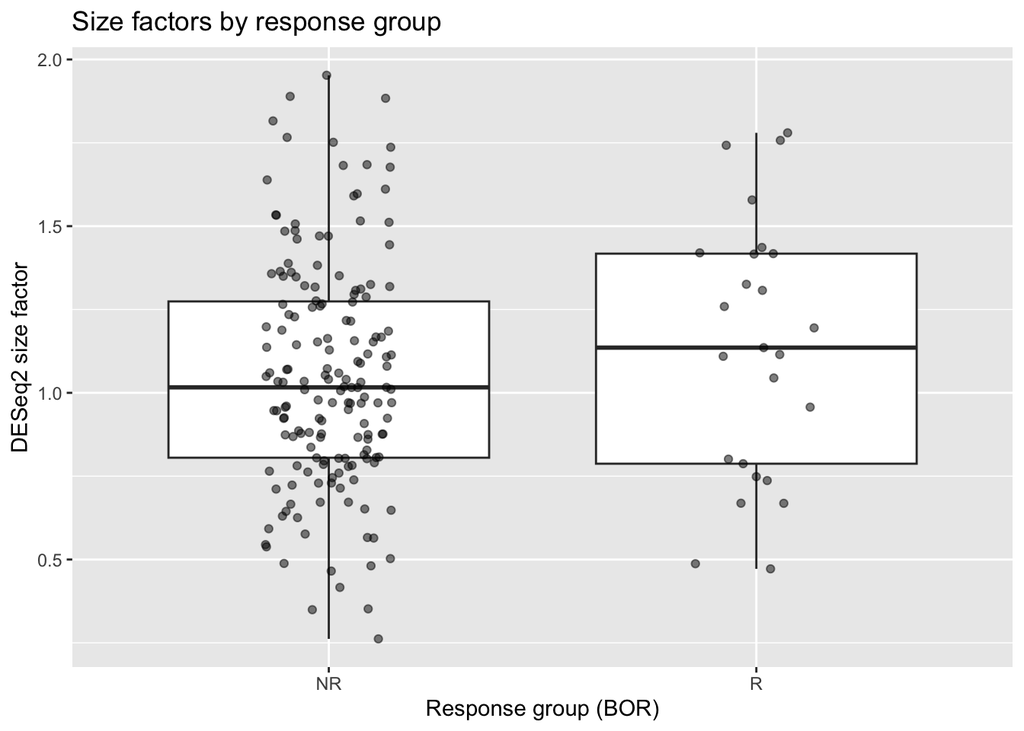

```r
# plot
ggplot(meta, aes(x = BOR, y = sizeFactor)) +
  geom_boxplot(outlier.shape = NA) +
  geom_jitter(width = 0.15, alpha = 0.5) +
  labs(x = "Response group (BOR)", y = "DESeq2 size factor",
       title = "Size factors by response group")
```

```r
# test for a difference between groups
wilcox.test(sizeFactor ~ BOR, data = meta)
```

```
    Wilcoxon rank sum test with continuity correction

data:  sizeFactor by BOR
W = 1818, p-value = 0.2992
alternative hypothesis: true location shift is not equal to 0
```

```r
# which samples are the lowest, and what group are they in
meta |>
  arrange(sizeFactor) |>
  select(sample_id, BOR, sizeFactor) |>
  head(10)
```

|  | sample_id | BOR | sizeFactor |
| --- | --- | --- | --- |
| SAM5cc2d9036053 | SAM5cc2d9036053 | NR | 0.2619507 |
| SAMbcb07ba81cee | SAMbcb07ba81cee | NR | 0.3494736 |
| SAM5234688806a7 | SAM5234688806a7 | NR | 0.3519590 |
| SAMda4d892fddc8 | SAMda4d892fddc8 | NR | 0.4164025 |
| SAM1f83ebd6be9b | SAM1f83ebd6be9b | NR | 0.4653806 |
| SAM2e9ac0b1b250 | SAM2e9ac0b1b250 | R | 0.4719743 |
| SAM7fb7a13c096b | SAM7fb7a13c096b | NR | 0.4810266 |
| SAM771445e92421 | SAM771445e92421 | R | 0.4874399 |
| SAM59fda9035d1d | SAM59fda9035d1d | NR | 0.4882530 |
| SAM94859b440b1d | SAM94859b440b1d | NR | 0.5027259 |

Size factors are roughly the same in both groups and there is no significant difference between groups. And anyway, DESeq accounts for size factors.

**Results**  
- alpha = 0.1: 290 were up (1.6%) and 491 down (2.7%) in responders, 781 in total  
- alpha = 0.05, 167 were up (0.92%) and 289 down (1.6%), 456 in total

Tightening the threshold removes 40% of the hits but the FDR is lover, will continue with this.

```r
cat("Genes with replaced outlier counts (mcols replace == TRUE):",
    sum(mcols(dds)$replace, na.rm = TRUE), "\n")
```

```
Genes with replaced outlier counts (mcols replace == TRUE): 1727
```

```r
# were any significant genes among the replaced ones?
replaced_genes <- rownames(dds)[which(mcols(dds)$replace)]
cat("Significant genes (padj < 0.05) with a replaced count:",
    sum(res_sig$padj < 0.05 & rownames(res_sig) %in% replaced_genes, na.rm = TRUE), "\n")
```

```
Significant genes (padj < 0.05) with a replaced count: 200
```

this means a lot of genes were flagged as outliers and replaced by DESeq default replacement. That’s why earlier it shows no outliers. Might be a limitation because so many of the significant genes just depend on replacement.

## Visualisation

```r
# DESeq results to dataframe for ggplot
res_df <- as_tibble(res_sig, rownames = "gene") |>
  # should not be any genes without padj but just in case
  drop_na(padj, log2FoldChange) |>
  mutate(
    group = case_when( # label by significance
      padj < 0.05 & log2FoldChange > 0 ~ "Higher in responders",
      padj < 0.05 & log2FoldChange < 0 ~ "Higher in non-responders",
      TRUE ~ "Not significant"
    )
  )

# check counts
table(res_df$group)
```

```
Higher in non-responders     Higher in responders          Not significant
                     289                      167                    17770
```

```r
# label 10 most significant genes on the plot
top_labels <- res_df |>
  filter(group != "Not significant") |>
  slice_min(padj, n = 10)

# who are they
top_labels$gene
```

```
 [1] "ALB"   "HABP2" "MYH15" "FGB"   "KRT75" "MUC2"  "TENM2" "MUC6"  "PRSS2"
[10] "WDR87"
```

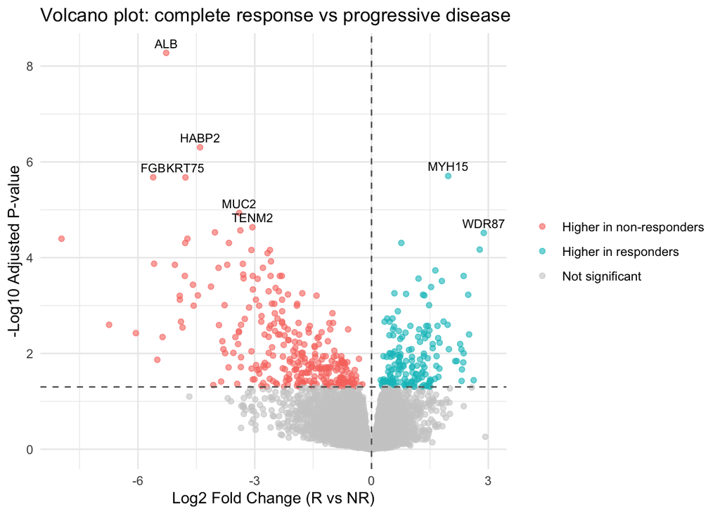

```r
ggplot(res_df, aes(x = log2FoldChange, y = -log10(padj))) +
  geom_point(aes(color = group), alpha = 0.6) +
  geom_vline(xintercept = 0, linetype = "dashed", color = "grey40") +
  geom_hline(yintercept = -log10(0.05), linetype = "dashed", color = "grey40") +
  scale_color_manual(
    name = NULL,
    values = c("Higher in responders"     = "#00BFC4",
               "Higher in non-responders" = "#F8766D",
               "Not significant"          = "grey80")
  ) +
  geom_text(data = top_labels, aes(label = gene),
            size = 3, vjust = -0.6, check_overlap = TRUE) +
  labs(x = "Log2 Fold Change (R vs NR)",
       y = "-Log10 Adjusted P-value",
       title = "Volcano plot: complete response vs progressive disease") +
  theme_minimal()
```

```r
ggsave("../results/plots/RQ1_volcano.png", width = 8, height = 6, dpi = 300)
```

456 genes are significant at padj < 0.05: 167 higher in responders and 289 higher in non-responders.

Genes in the top-right corner (large positive log2FC, very small padj) are strongly and confidently upregulated in complete responders.  
Genes in the top-left corner (large negative log2FC, very small padj) are strongly upregulated in patients with progressive disease.  
Points near the bottom are not statistically significant, even when the fold change looks large. Points near the middle are significant but have small effect sizes.

```r
res_df |> filter(gene %in% top_labels$gene) |> select(gene, log2FoldChange, padj)
```

| gene | log2FoldChange | padj |
| --- | --- | --- |
| ALB | -5.274502 | 5.299539e-09 |
| FGB | -5.608898 | 2.097765e-06 |
| MYH15 | 1.969631 | 1.969334e-06 |
| HABP2 | -4.404441 | 4.961437e-07 |
| MUC2 | -3.400420 | 1.171405e-05 |
| MUC6 | -3.369656 | 2.697155e-05 |
| PRSS2 | -4.022277 | 2.963374e-05 |
| TENM2 | -3.059741 | 2.316599e-05 |
| WDR87 | 2.884126 | 3.034505e-05 |
| KRT75 | -4.779969 | 2.109999e-06 |

```r
sig <- res_df |>
  filter(group != "Not significant")

cat("Significant genes (padj < 0.05):", nrow(sig), "\n")
```

```
Significant genes (padj < 0.05): 456
```

```r
for (t in c(0.5, 1, 1.5, 2)) {
  cat("  with |log2FC| >", t, ":", sum(abs(sig$log2FoldChange) > t), "\n")
}
```

```
  with |log2FC| > 0.5 : 414
  with |log2FC| > 1 : 309
  with |log2FC| > 1.5 : 215
  with |log2FC| > 2 : 142
```

```r
cat("Median |log2FC| among significant genes:",
    round(median(abs(sig$log2FoldChange)), 2), "\n")
```

```
Median |log2FC| among significant genes: 1.45
```

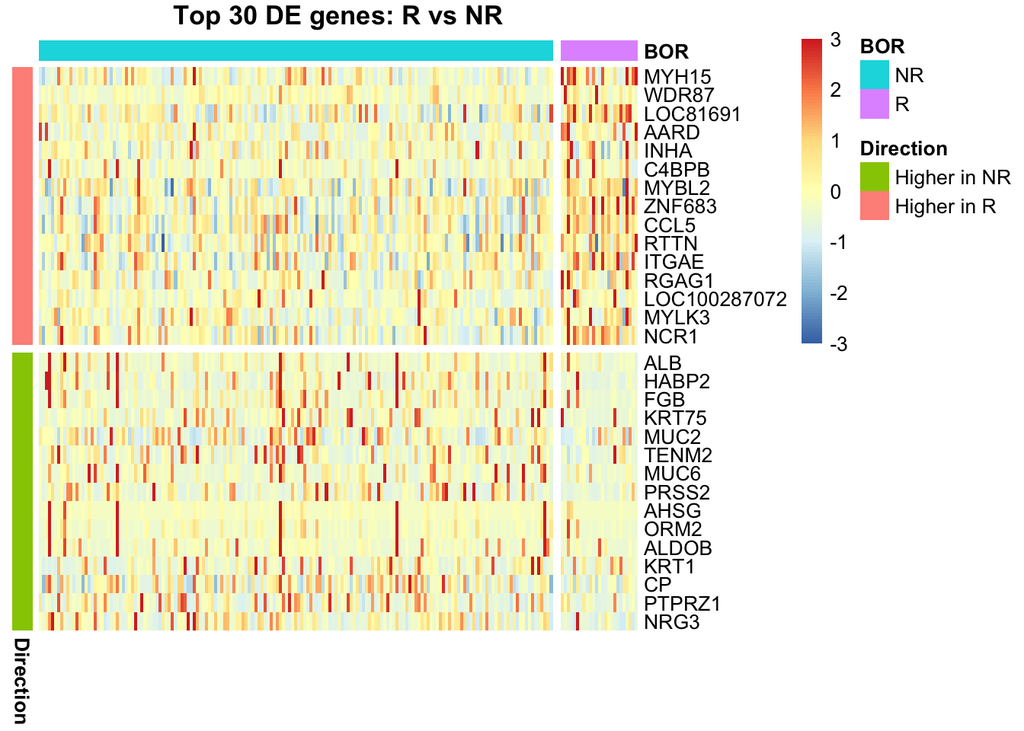

```r
# variance-stabilized counts (same model/normalization as the DE test)
# transforms to log scale
vsd <- vst(dds, blind = FALSE)
# get matrix
vsd_mat <- assay(vsd)

# top 15 genes in each direction, by adjusted p-value
top_up   <- res_df |> filter(group == "Higher in responders") |>
  slice_min(padj, n = 15) |> pull(gene)
top_down <- res_df |> filter(group == "Higher in non-responders") |>
  slice_min(padj, n = 15) |> pull(gene)
top_genes <- c(top_up, top_down)

# annotations (rownames must match the heatmap's column / row names)
annotation_col <- data.frame(BOR = colData(dds)$BOR,
                             row.names = colnames(vsd_mat))
annotation_row <- data.frame(
  Direction = rep(c("Higher in R", "Higher in NR"),
                  c(length(top_up), length(top_down))),
  row.names = top_genes)

# heatmap, samples ordered by response group
sample_order <- order(colData(dds)$BOR)

ph <- pheatmap(vsd_mat[top_genes, sample_order],
               annotation_col = annotation_col,
               annotation_row = annotation_row,
               scale = "row",
               cluster_rows = FALSE,
               gaps_row = length(top_up),
               cluster_cols = FALSE,
               gaps_col = sum(colData(dds)$BOR == "NR"),
               show_colnames = FALSE,
               breaks = seq(-3, 3, length.out = 101),
               main = "Top 30 DE genes: R vs NR")
```

```r
# save a copy to file
png("../results/plots/RQ1_heatmap.png", width = 9, height = 8, units = "in", res = 300)
grid::grid.newpage()
grid::grid.draw(ph$gtable)
dev.off()
```

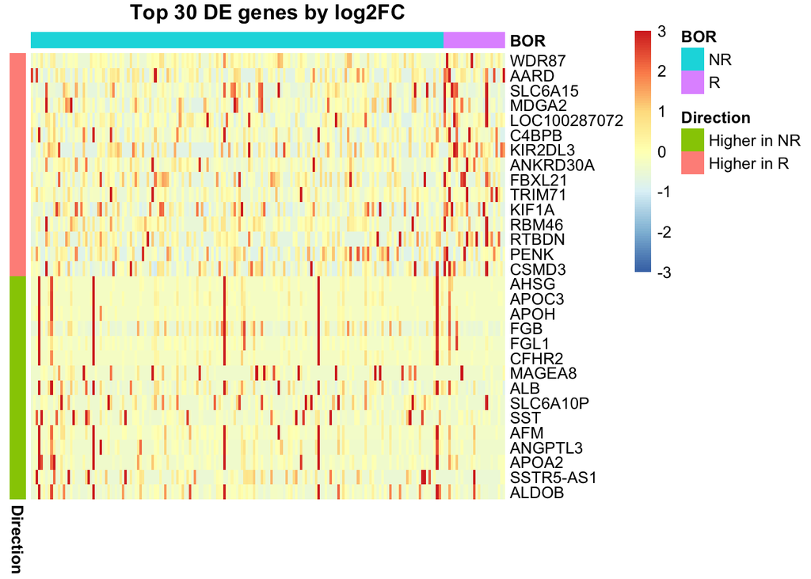

```r
# 15 biggest log2FC in each direction, among significant genes
lfc_up   <- res_df |> filter(group == "Higher in responders") |>
  slice_max(log2FoldChange, n = 15) |> pull(gene)
lfc_down <- res_df |> filter(group == "Higher in non-responders") |>
  slice_min(log2FoldChange, n = 15) |> pull(gene)
lfc_genes <- c(lfc_up, lfc_down)

annotation_row_lfc <- data.frame(
  Direction = rep(c("Higher in R", "Higher in NR"), c(15, 15)),
  row.names = lfc_genes)

pheatmap(vsd_mat[lfc_genes, sample_order],
         annotation_col = annotation_col,
         annotation_row = annotation_row_lfc,
         scale = "row",
         cluster_rows = FALSE,
         cluster_cols = FALSE,
         show_colnames = FALSE,
         breaks = seq(-3, 3, length.out = 101),
         main = "Top 30 DE genes by log2FC")
```

## GSEA

```r
# Rank genes by Wald statistic
ranked_genes <- res$stat
names(ranked_genes) <- rownames(res)

# remove NA statistics and genes with empty or missing names
ranked_genes <- ranked_genes[!is.na(ranked_genes)]
ranked_genes <- ranked_genes[!is.na(names(ranked_genes)) & names(ranked_genes) != ""]

# check for duplicated gene names
sum(duplicated(names(ranked_genes)))
```

```
[1] 0
```

```r
cat("Genes in ranked list:", length(ranked_genes), "\n")
```

```
Genes in ranked list: 18225
```

```r
cat("Top 6 genes higher in responders (highest Wald stat):\n")
```

```
Top 6 genes higher in responders (highest Wald stat):
```

```r
print(round(head(sort(ranked_genes, decreasing = TRUE)), 2))
```

```
   MYH15    WDR87 LOC81691     AARD     INHA    C4BPB
    6.29     5.64     5.51     5.42     5.14     5.05
```

```r
cat("Top 6 genes higher in non-responders (lowest Wald stat):\n")
```

```
Top 6 genes higher in non-responders (lowest Wald stat):
```

```r
print(round(head(sort(ranked_genes)), 2))
```

```
  ALB HABP2   FGB KRT75  MUC2 TENM2
-7.30 -6.56 -6.23 -6.20 -5.89 -5.75
```

One gene got removed because it did not have a name.

```r
# fgsea against MSigDB gene sets

gene_sets <- msigdbr(species = "Homo sapiens", collection = "C5", subcollection = "BP")
gene_sets <- split(x = gene_sets$gene_symbol, f = gene_sets$gs_name)

length(gene_sets)
```

```
[1] 7538
```

```r
set.seed(42)
fgsea_res <- fgsea(pathways = gene_sets,
                   stats = ranked_genes,
                   nPermSimple = 10000)
```

```r
# how many pathways are significant, and in which direction?
cat("Significant pathways (padj < 0.05):",
    sum(fgsea_res$padj < 0.05, na.rm = TRUE), "\n")
```

```
Significant pathways (padj < 0.05): 1223
```

```r
cat("  enriched in responders (NES > 0):",
    sum(fgsea_res$padj < 0.05 & fgsea_res$NES > 0, na.rm = TRUE), "\n")
```

```
  enriched in responders (NES > 0): 459
```

```r
cat("  enriched in non-responders (NES < 0):",
    sum(fgsea_res$padj < 0.05 & fgsea_res$NES < 0, na.rm = TRUE), "\n")
```

```
  enriched in non-responders (NES < 0): 764
```

```r
cat("Pathways with NA padj:", sum(is.na(fgsea_res$padj)), "\n")                                    #
```

```
Pathways with NA padj: 0
```

7,538 GO Biological Process gene sets were tested, and 1,223 are significant at padj < 0.05 (about 16%)  
459 have a positive NES, meaning they are enriched among genes higher in complete responders. 764 have a negative NES, meaning they are enriched among genes higher in non-responders (progressive disease)  
No pathways returned NA p-values.

```r
cat("Smallest / largest tested pathway size:", range(fgsea_res$size), "\n")
```

```
Smallest / largest tested pathway size: 1 1788
```

```r
cat("Pathways tested:", nrow(fgsea_res), "of", length(gene_sets), "input sets\n")
```

```
Pathways tested: 7534 of 7538 input sets
```

### GSEA visualisation

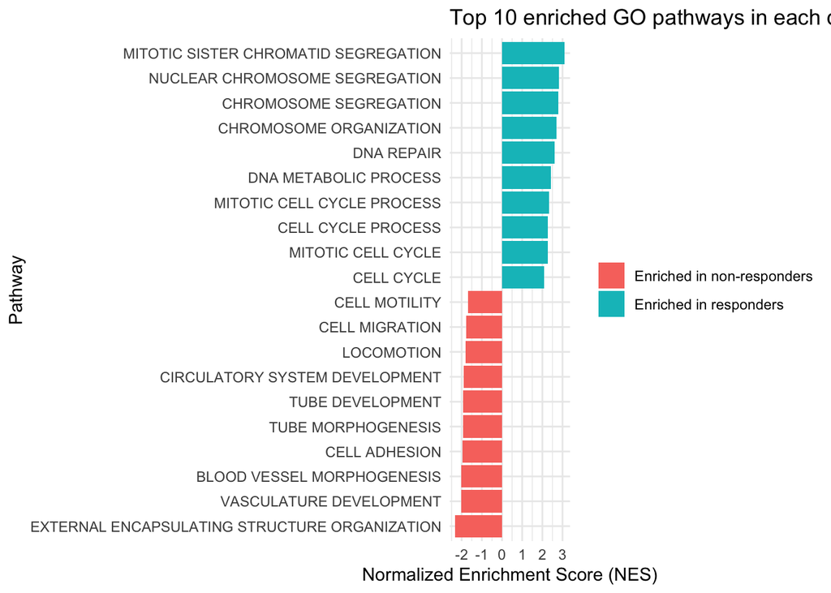

```r
top_bar <- bind_rows(
  fgsea_res |> dplyr::filter(NES > 0) |> dplyr::arrange(padj) |> head(10),
  fgsea_res |> dplyr::filter(NES < 0) |> dplyr::arrange(padj) |> head(10)
) |>
  mutate(pathway_clean = str_remove(pathway, "^GOBP_") |> str_replace_all("_", " "),
         direction = ifelse(NES > 0, "Enriched in responders", "Enriched in non-responders"))

ggplot(top_bar, aes(x = reorder(pathway_clean, NES), y = NES, fill = direction)) +
  geom_col() +
  coord_flip() +
  scale_fill_manual(name = NULL,
                    values = c("Enriched in responders" = "#00BFC4",
                               "Enriched in non-responders" = "#F8766D")) +
  labs(x = "Pathway",
       y = "Normalized Enrichment Score (NES)",
       title = "Top 10 enriched GO pathways in each direction") +
  theme_minimal()
```

#### PATHWAYS

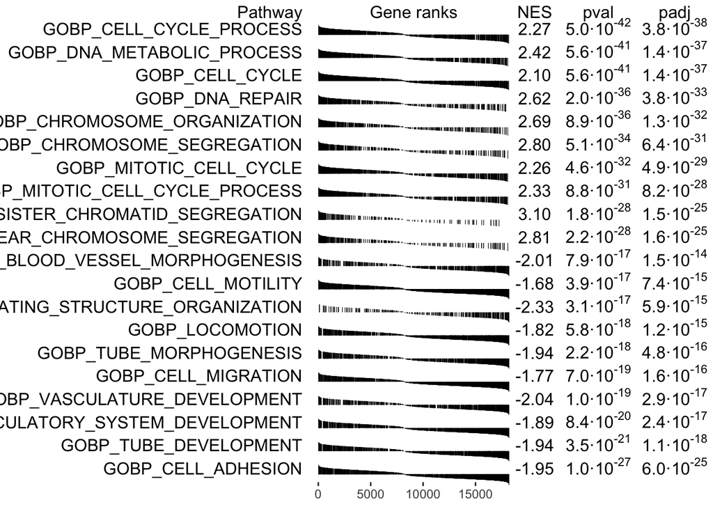

```r
# table plots
#| fig-width: 18
#| fig-height: 10

topPathwaysUp <- fgsea_res |> filter(NES > 0) |>
                                arrange(pval) |>
                                head(10) |>
                                pull(pathway)

topPathwaysDown <- fgsea_res |> filter(NES < 0) |>
                                arrange(pval) |>
                                head(10) |>
                                pull(pathway)

topPathways <- c(topPathwaysUp, rev(topPathwaysDown))

# show in the doc
plotGseaTable(gene_sets[topPathways], stats = ranked_genes,
              fgseaRes = fgsea_res, gseaParam = 0.5)
```

```r
# save PNG
png("../results/plots/RQ1_gsea_table.png", width = 20, height = 15, units = "in", res = 300)
plotGseaTable(gene_sets[topPathways], stats = ranked_genes,
              fgseaRes = fgsea_res, gseaParam = 0.5)
dev.off()
```

```r
topPathwaysUp
```

```
 [1] "GOBP_CELL_CYCLE_PROCESS"
 [2] "GOBP_DNA_METABOLIC_PROCESS"
 [3] "GOBP_CELL_CYCLE"
 [4] "GOBP_DNA_REPAIR"
 [5] "GOBP_CHROMOSOME_ORGANIZATION"
 [6] "GOBP_CHROMOSOME_SEGREGATION"
 [7] "GOBP_MITOTIC_CELL_CYCLE"
 [8] "GOBP_MITOTIC_CELL_CYCLE_PROCESS"
 [9] "GOBP_MITOTIC_SISTER_CHROMATID_SEGREGATION"
[10] "GOBP_NUCLEAR_CHROMOSOME_SEGREGATION"
```

```r
topPathwaysDown
```

```
 [1] "GOBP_CELL_ADHESION"
 [2] "GOBP_TUBE_DEVELOPMENT"
 [3] "GOBP_CIRCULATORY_SYSTEM_DEVELOPMENT"
 [4] "GOBP_VASCULATURE_DEVELOPMENT"
 [5] "GOBP_CELL_MIGRATION"
 [6] "GOBP_TUBE_MORPHOGENESIS"
 [7] "GOBP_LOCOMOTION"
 [8] "GOBP_EXTERNAL_ENCAPSULATING_STRUCTURE_ORGANIZATION"
 [9] "GOBP_CELL_MOTILITY"
[10] "GOBP_BLOOD_VESSEL_MORPHOGENESIS"
```

```r
set.seed(42)
collapsed <- collapsePathways(fgsea_res[order(pval)][pval < 0.05],
                              gene_sets, ranked_genes)

length(collapsed$mainPathways)
```

```
[1] 343
```

```r
mainPathways <- fgsea_res[pathway %in% collapsed$mainPathways][order(-NES)]

mainPathways[NES > 0][order(padj)][1:10, .(pathway, NES, padj, size)]
```

| pathway | NES | padj | size |
| --- | --- | --- | --- |
| GOBP_CELL_CYCLE_PROCESS | 2.273647 | 3.788279e-38 | 1220 |
| GOBP_DNA_METABOLIC_PROCESS | 2.420114 | 1.418304e-37 | 916 |
| GOBP_CELL_CYCLE | 2.100024 | 1.418304e-37 | 1544 |
| GOBP_DNA_REPAIR | 2.616421 | 3.779562e-33 | 572 |
| GOBP_CHROMOSOME_ORGANIZATION | 2.693336 | 1.334001e-32 | 510 |
| GOBP_CHROMOSOME_SEGREGATION | 2.796014 | 6.390054e-31 | 404 |
| GOBP_MITOTIC_CELL_CYCLE | 2.257389 | 4.898341e-29 | 876 |
| GOBP_MITOTIC_CELL_CYCLE_PROCESS | 2.331522 | 8.241773e-28 | 736 |
| GOBP_MITOTIC_SISTER_CHROMATID_SEGREGATION | 3.101141 | 1.521479e-25 | 194 |
| GOBP_ORGANELLE_FISSION | 2.544799 | 2.334016e-25 | 463 |

```r
mainPathways[NES < 0][order(padj)][1:10, .(pathway, NES, padj, size)]
```

| pathway | NES | padj | size |
| --- | --- | --- | --- |
| GOBP_CELL_ADHESION | -1.945739 | 5.957515e-25 | 1433 |
| GOBP_TUBE_DEVELOPMENT | -1.938509 | 1.060398e-18 | 1041 |
| GOBP_CIRCULATORY_SYSTEM_DEVELOPMENT | -1.891752 | 2.428055e-17 | 1078 |
| GOBP_VASCULATURE_DEVELOPMENT | -2.036793 | 2.904954e-17 | 727 |
| GOBP_CELL_MIGRATION | -1.765468 | 1.649758e-16 | 1411 |
| GOBP_LOCOMOTION | -1.820465 | 1.185734e-15 | 1121 |
| GOBP_EXTERNAL_ENCAPSULATING_STRUCTURE_ORGANIZATION | -2.326989 | 5.942740e-15 | 314 |
| GOBP_ENZYME_LINKED_RECEPTOR_PROTEIN_SIGNALING_PATHWAY | -1.840512 | 2.283220e-14 | 944 |
| GOBP_ANIMAL_ORGAN_MORPHOGENESIS | -1.849349 | 8.891303e-14 | 936 |
| GOBP_WOUND_HEALING | -2.116893 | 1.392762e-13 | 417 |

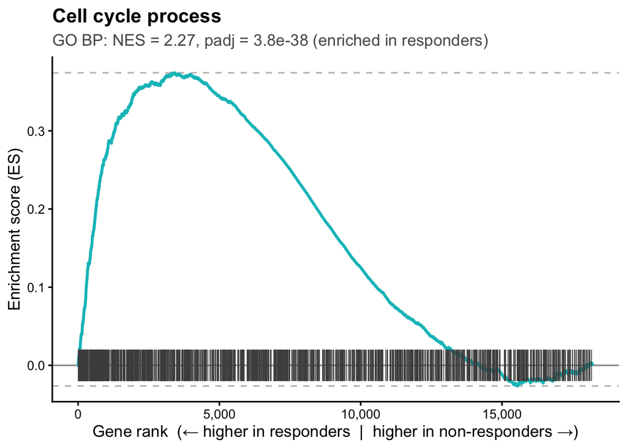

```r
plot_enrichment_curve <- function(pw, title = NULL) {
  pd  <- plotEnrichmentData(pathway = gene_sets[[pw]], stats = ranked_genes)
  row <- fgsea_res[fgsea_res$pathway == pw, ]

  curve_col <- ifelse(row$NES > 0, "#00BFC4", "#F8766D")
  direction <- ifelse(row$NES > 0, "enriched in responders", "enriched in non-responders")
  if (is.null(title)) title <- pw |> str_remove("^GOBP_") |> str_replace_all("_", " ") |> str_to_sentence()

  ggplot(pd$curve, aes(x = rank, y = ES)) +
    geom_hline(yintercept = 0, color = "grey60") +
    geom_hline(yintercept = c(pd$posES, pd$negES), linetype = "dashed", color = "grey75") +
    geom_line(color = curve_col, linewidth = 1.1) +
    geom_segment(
      data = pd$ticks,
      aes(x = rank, xend = rank, y = -pd$spreadES / 20, yend = pd$spreadES / 20),
      linewidth = 0.3, color = "grey30"
    ) +
    scale_x_continuous(
      name = "Gene rank  (\u2190 higher in responders  |  higher in non-responders \u2192)",
      labels = scales::comma
    ) +
    scale_y_continuous(name = "Enrichment score (ES)") +
    labs(
      title = title,
      subtitle = sprintf("GO BP: NES = %.2f, padj = %.1e (%s)", row$NES, row$padj, direction)
    ) +
    theme_classic(base_size = 13) +
    theme(
      plot.title = element_text(face = "bold"),
      plot.subtitle = element_text(color = "grey35")
    )
}

top_up   <- fgsea_res[NES > 0][order(padj)][1, pathway]
top_down <- fgsea_res[NES < 0][order(padj)][1, pathway]

p_up   <- plot_enrichment_curve(top_up)
p_down <- plot_enrichment_curve(top_down)

p_up
```

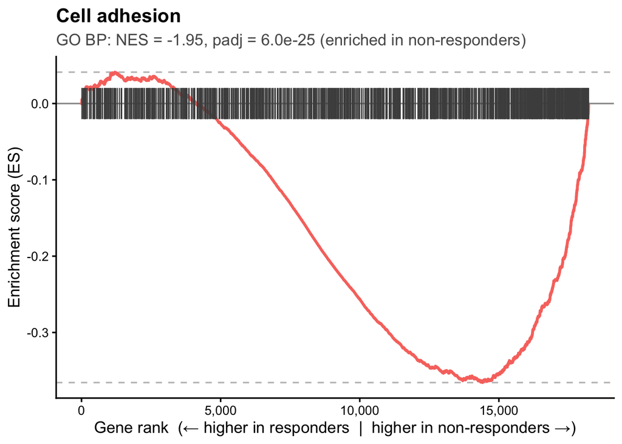

```r
p_down
```

```r
ggsave("../results/plots/RQ1_enrichment_up.png",   p_up,   width = 9, height = 5, dpi = 300)
ggsave("../results/plots/RQ1_enrichment_down.png", p_down, width = 9, height = 5, dpi = 300)
```

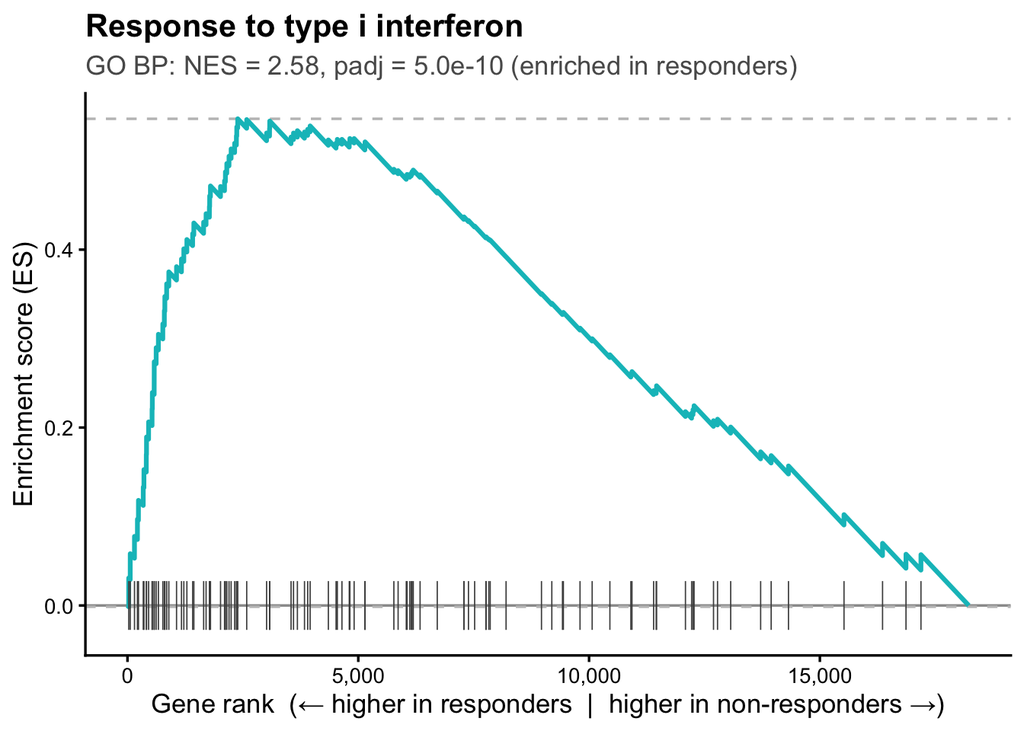

```r
p_ifn <- plot_enrichment_curve("GOBP_RESPONSE_TO_TYPE_I_INTERFERON")
p_ifn
```

```r
ggsave("../results/plots/RQ1_enrichment_ifn.png", p_ifn, width = 9, height = 5, dpi = 300)
```